# Stat Rethinking Chapter 5

# Set up

Load required libraries

```r
library(rethinking, quietly = TRUE)
library(tidyverse, quietly = TRUE)
library(DT, quietly = TRUE)
```

# Chapter 5

## Q5H1

Load the foxes data and view:

```r
data(foxes)
knitr::kable(foxes[1:10,])
```

| group | avgfood | groupsize | area | weight |
| --- | --- | --- | --- | --- |
| 1 | 0.37 | 2 | 1.09 | 5.02 |
| 1 | 0.37 | 2 | 1.09 | 2.84 |
| 2 | 0.53 | 2 | 2.05 | 5.33 |
| 2 | 0.53 | 2 | 2.05 | 6.07 |
| 3 | 0.49 | 2 | 2.12 | 5.85 |
| 3 | 0.49 | 2 | 2.12 | 3.25 |
| 4 | 0.45 | 2 | 1.29 | 4.53 |
| 4 | 0.45 | 2 | 1.29 | 4.09 |
| 5 | 0.74 | 3 | 3.78 | 6.13 |
| 5 | 0.74 | 3 | 3.78 | 5.59 |

### Weight vs Area

Fit a bivariate Gaussian regression for body weight as a linear function of territory size:

```r
m5h1_flist <- alist(
        weight ~ dnorm( mu , sigma ) ,
        mu <- a + b*area ,
        a ~ dnorm( 4.5 , 10 ) ,
        b ~ dnorm( 0 , 100 ) ,
        sigma ~ dunif( 0 , 50 )
)

m5h1 <- rethinking::map( m5h1_flist , data=foxes )
```

Quickly look at the parameter estimates:

```r
precis(m5h1)
```

```
##       Mean StdDev  5.5% 94.5%
## a     4.45   0.39  3.83  5.08
## b     0.02   0.12 -0.16  0.21
## sigma 1.18   0.08  1.06  1.30
```

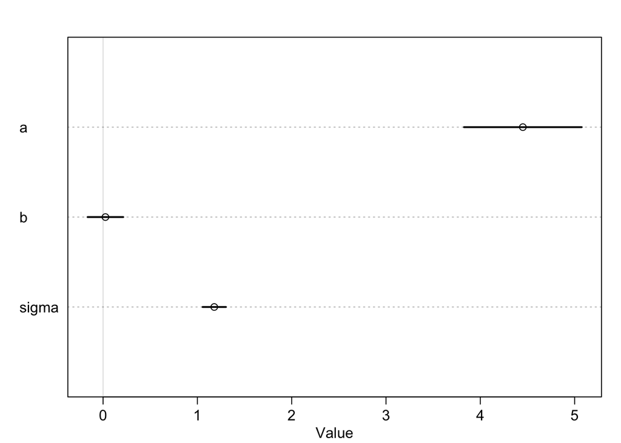

```r
plot(precis(m5h1))
```

```r
#use link to generate MAP line and its HPDI
m5h1.area.seq <- seq( from=0.5, to=7 , by = 0.1 )
m5h1.mu <- link( m5h1 , data=list(area=m5h1.area.seq ))
```

[output not shown]

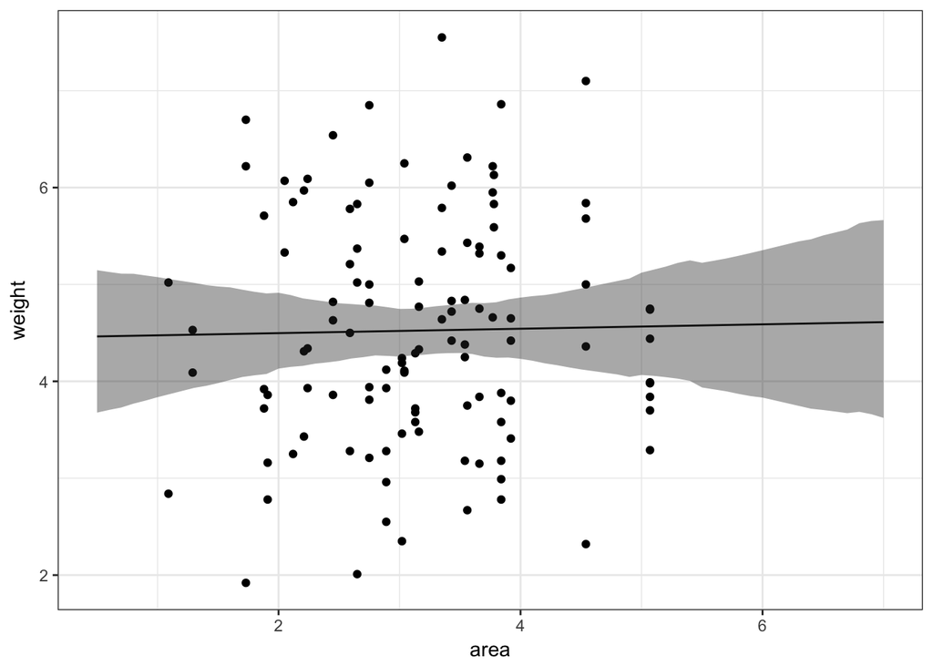

```r
m5h1.mu.mean <- apply( m5h1.mu , 2 , mean )
m5h1.mu.HPDI <- apply( m5h1.mu , 2 , HPDI , prob=0.97 )

#make a data frame of model predictions for plotting
m5h1_model_plot_dat <- data.frame(area=m5h1.area.seq,
                             weight=m5h1.mu.mean,
                             mu_pi_lower=m5h1.mu.HPDI[1,],
                             mu_pi_upper=m5h1.mu.HPDI[2,])

#do plot with ggplot2
library(ggplot2)
ggplot(foxes, aes(area, weight)) +
    geom_point() +
    geom_line(data=m5h1_model_plot_dat) +
    geom_ribbon(data=m5h1_model_plot_dat, aes(x=area, ymin=mu_pi_lower, ymax=mu_pi_upper),
                alpha=0.4)  +
    theme_bw()
```

Fit a bivariate Gaussian regression for body weight as a linear function of group size:

```r
m5h1b_flist <- alist(
        weight ~ dnorm( mu , sigma ) ,
        mu <- a + b*groupsize ,
        a ~ dnorm( 4.5 , 10 ) ,
        b ~ dnorm( 0 , 100 ) ,
        sigma ~ dunif( 0 , 50 )
)

m5h1b <- rethinking::map( m5h1b_flist , data=foxes )
```

Quickly look at the parameter estimates:

```r
precis(m5h1b)
```

```
##        Mean StdDev  5.5% 94.5%
## a      5.07   0.32  4.55  5.59
## b     -0.12   0.07 -0.24 -0.01
## sigma  1.16   0.08  1.04  1.29
```

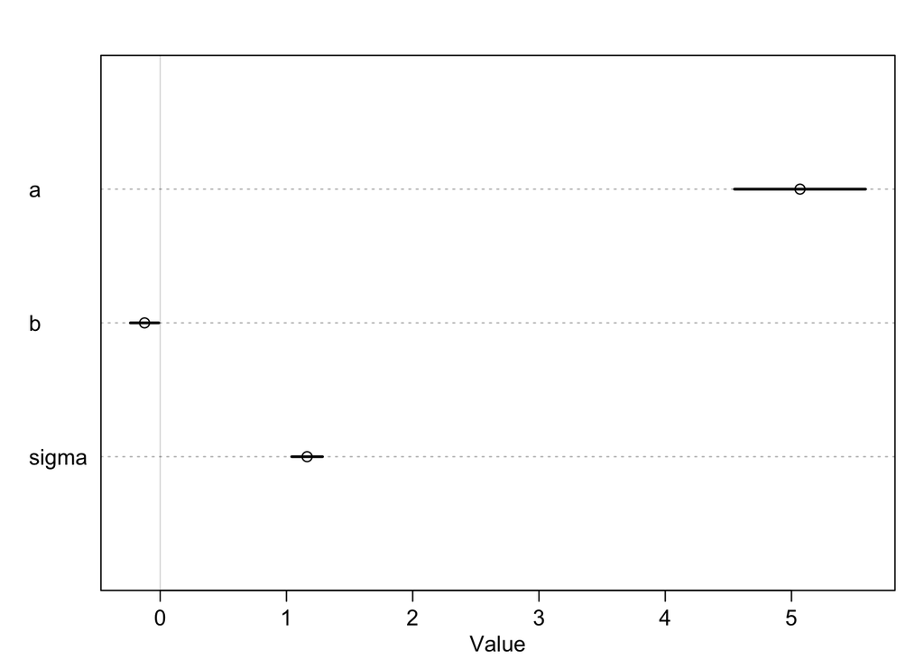

```r
plot(precis(m5h1b))
```

```r
#use link to generate MAP line and its HPDI
m5h1b.groupsize.seq <- seq( from=1, to=9 , by = 0.2 )
m5h1b.mu <- link( m5h1b , data=list(groupsize=m5h1b.groupsize.seq ))
```

[output not shown]

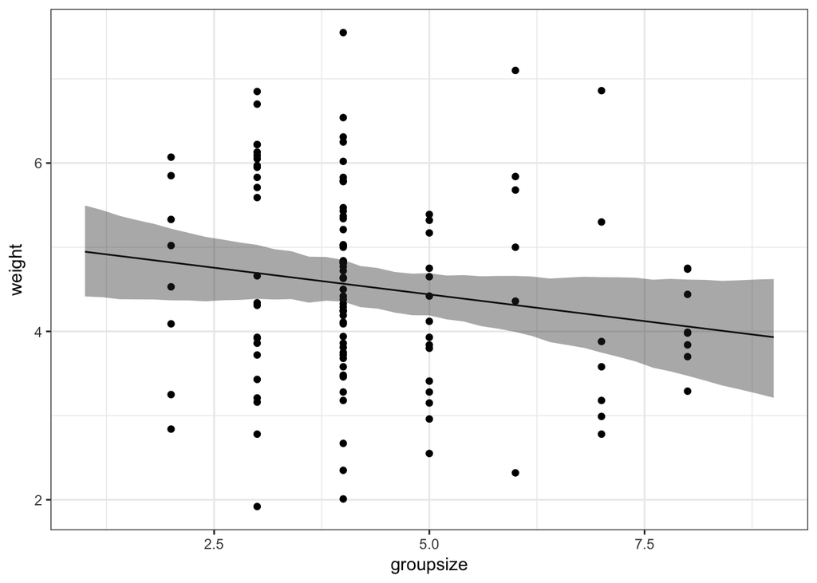

```r
m5h1b.mu.mean <- apply( m5h1b.mu , 2 , mean )
m5h1b.mu.HPDI <- apply( m5h1b.mu , 2 , HPDI , prob=0.97 )

#make a data frame of model predictions for plotting
m5h1b_model_plot_dat <- data.frame(groupsize=m5h1b.groupsize.seq,
                             weight=m5h1b.mu.mean,
                             mu_pi_lower=m5h1b.mu.HPDI[1,],
                             mu_pi_upper=m5h1b.mu.HPDI[2,])

#do plot with ggplot2
library(ggplot2)
ggplot(foxes, aes(groupsize, weight)) +
    geom_point() +
    geom_line(data=m5h1b_model_plot_dat) +
    geom_ribbon(data=m5h1b_model_plot_dat, aes(x=groupsize, ymin=mu_pi_lower, ymax=mu_pi_upper),
                alpha=0.4)  +
    theme_bw()
```

## Q5H2

In this question we want to see the effect of including both groupsize AND area in the regression.

### Fit a multiple linear regression

```r
m5h2_flist <- alist(
        weight ~ dnorm( mu , sigma ) ,
        mu <- a + bG*groupsize + bA*area ,
        a ~ dnorm( 4.5 , 10 ) ,
        bG ~ dnorm( 0 , 100 ) ,
        bA ~ dnorm( 0 , 100 ) ,
        sigma ~ dunif( 0 , 50 )
)

m5h2 <- rethinking::map( m5h2_flist , data=foxes )
```

Quickly look at the parameter estimates:

```r
precis(m5h2)
```

```
##        Mean StdDev  5.5% 94.5%
## a      4.45   0.37  3.86  5.04
## bG    -0.43   0.12 -0.63 -0.24
## bA     0.62   0.20  0.30  0.94
## sigma  1.12   0.07  1.00  1.24
```

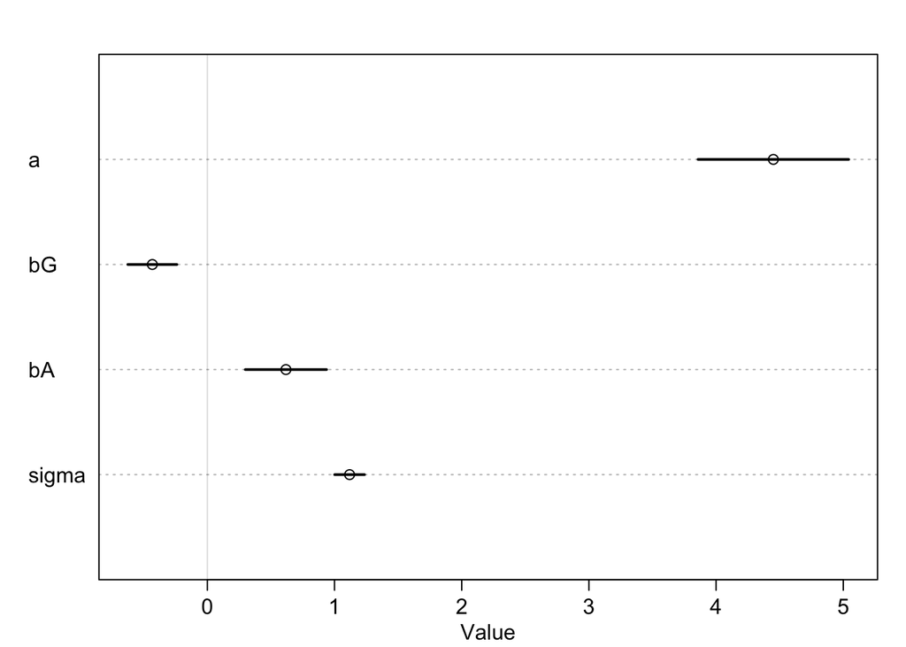

```r
plot(precis(m5h2))
```

Now the variables do look more important since - larger group size seems to negatively impact weight whereas larger area size positively impacts weight.

### Counterfactual plots

#### Group Size Counterfactual

First explore groupsize:

```r
#set up prediction data
pred_data_m5h2a <- data.frame(area=mean(foxes$area),
                        groupsize=seq( from=1, to=9 , by = 0.2 ))

#predict mu from model
mu_m5h2a <- link(m5h2, data=pred_data_m5h2a, n=1e4)
```

[output not shown]

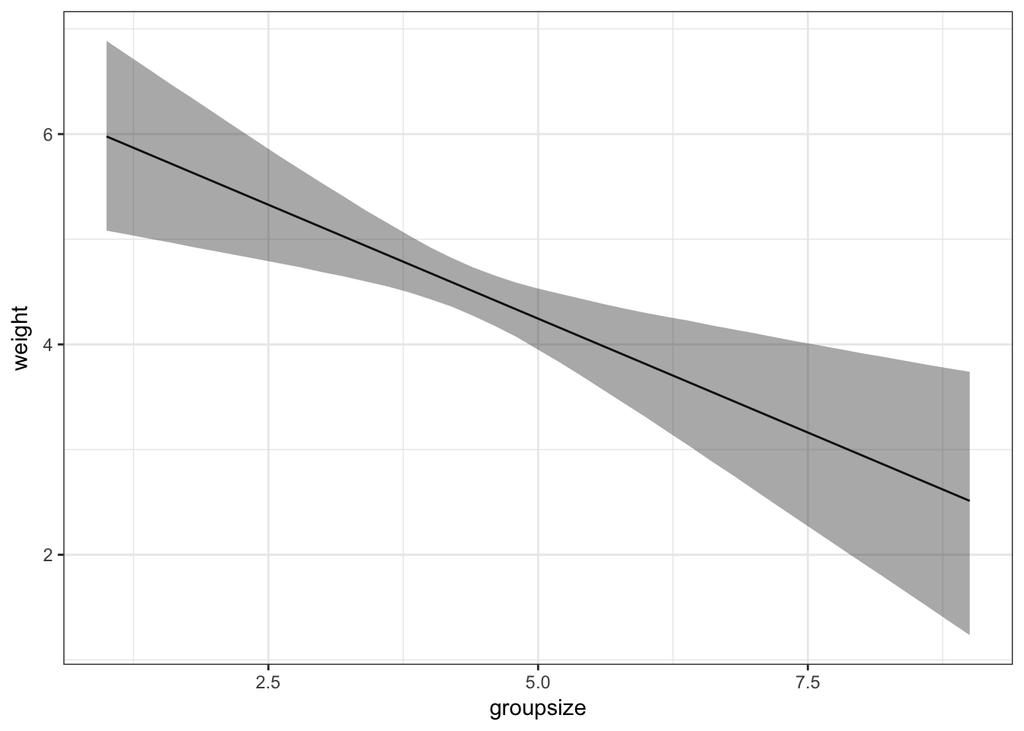

```r
mu_mean_m5h2a <- apply(mu_m5h2a, 2, mean)
mu_PI_m5h2a <- apply(mu_m5h2a, 2, PI, prob=0.975 )

#make a data frame of model predictions for plotting
m5h2a_model_plot_dat <- data.frame(area = pred_data_m5h2a$area,
                             groupsize=pred_data_m5h2a$groupsize,
                             weight=mu_mean_m5h2a,
                             mu_pi_lower=mu_PI_m5h2a[1,],
                             mu_pi_upper=mu_PI_m5h2a[2,])

#do plot with ggplot2
ggplot(m5h2a_model_plot_dat, aes(groupsize, weight)) +
    geom_line(data=m5h2a_model_plot_dat) +
    geom_ribbon(data=m5h2a_model_plot_dat, aes(x=groupsize, ymin=mu_pi_lower, ymax=mu_pi_upper),
                alpha=0.4)  +
    theme_bw()
```

#### Area Counterfactual

Now area:

```r
#set up prediction data
pred_data_m5h2b <- data.frame(area=seq( from=0.5, to=7 , by = 0.1 ),
                        groupsize=mean(foxes$groupsize))

#predict mu from model
mu_m5h2b <- link(m5h2, data=pred_data_m5h2b, n=1e4)
```

[output not shown]

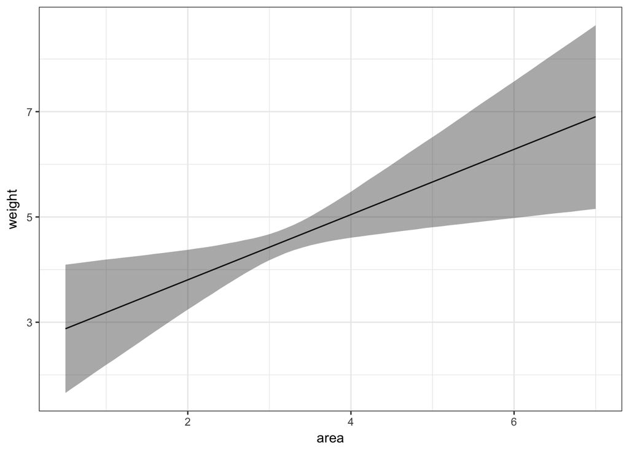

```r
mu_mean_m5h2b <- apply(mu_m5h2b, 2, mean)
mu_PI_m5h2b <- apply(mu_m5h2b, 2, PI, prob=0.975 )

#make a data frame of model predictions for plotting
m5h2b_model_plot_dat <- data.frame(area = pred_data_m5h2b$area,
                             area=pred_data_m5h2b$groupsize,
                             weight=mu_mean_m5h2b,
                             mu_pi_lower=mu_PI_m5h2b[1,],
                             mu_pi_upper=mu_PI_m5h2b[2,])

#do plot with ggplot2
ggplot(m5h2b_model_plot_dat, aes(area, weight)) +
    geom_line(data=m5h2b_model_plot_dat) +
    geom_ribbon(data=m5h2b_model_plot_dat, aes(x=area, ymin=mu_pi_lower, ymax=mu_pi_upper),
                alpha=0.4)  +
    theme_bw()
```

### Conclusion

Including both variables in the model shows that area has a positive impact on weight whilst groupsize has a negative impact on weight. THe size of the effects is bigger than when the variables were examined in seperate models. This is due to the masking effect where two variables with effects in opposite directions can mask eachother out unless considered together.

## Q5C

### Model with avgfood and groupsize

Fit multiple linear regression with avgfood and groupsize:

```r
m5h3a_flist <- alist(
        weight ~ dnorm( mu , sigma ) ,
        mu <- a + bG*groupsize + bF*avgfood ,
        a ~ dnorm( 4.5 , 10 ) ,
        bG ~ dnorm( 0 , 100 ) ,
        bF ~ dnorm( 0 , 100 ) ,
        sigma ~ dunif( 0 , 50 )
)

m5h3a <- rethinking::map( m5h3a_flist , data=foxes )
```

Quickly look at the parameter estimates:

```r
precis(m5h3a)
```

```
##        Mean StdDev  5.5% 94.5%
## a      4.12   0.43  3.43  4.81
## bG    -0.57   0.16 -0.82 -0.32
## bF     3.83   1.21  1.89  5.76
## sigma  1.12   0.07  1.00  1.23
```

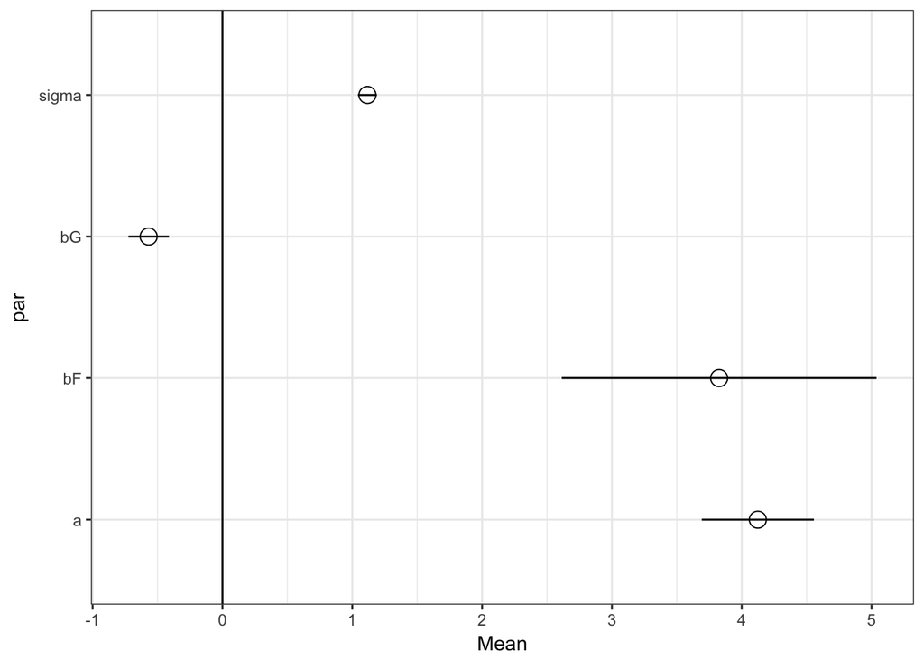

```r
precis(m5h3a)@output %>%
    tibble::rownames_to_column('par') %>%
    ggplot(aes(x=par, y=Mean)) +
    geom_linerange(aes(ymin=Mean-StdDev, ymax=Mean+StdDev)) +
    geom_point(size=4, shape=1) +
    theme_bw() + coord_flip() + geom_hline(yintercept = 0)
```

### Model with avgfood, groupsize and area

Now fit model including avgfood, groupsize and area:

```r
m5h3b_flist <- alist(
        weight ~ dnorm( mu , sigma ) ,
        mu <- a + bG*groupsize + bF*avgfood + bA*area,
        a ~ dnorm( 4.5 , 10 ) ,
        bG ~ dnorm( 0 , 100 ) ,
        bF ~ dnorm( 0 , 100 ) ,
        bA ~ dnorm( 0 , 100 ) ,
        sigma ~ dunif( 0 , 50 )
)

m5h3b <- rethinking::map( m5h3b_flist , data=foxes )
```

Quickly look at the parameter estimates:

```r
precis(m5h3b)
```

```
##        Mean StdDev  5.5% 94.5%
## a      4.06   0.43  3.38  4.75
## bG    -0.61   0.16 -0.86 -0.36
## bF     2.51   1.45  0.19  4.83
## bA     0.39   0.24  0.00  0.77
## sigma  1.10   0.07  0.99  1.22
```

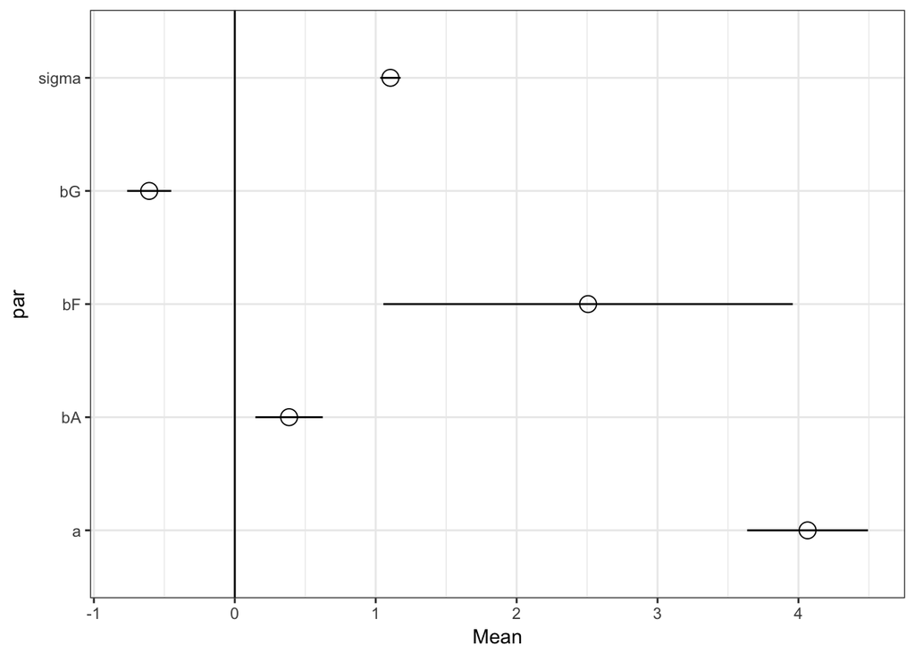

```r
precis(m5h3b)@output %>%
    tibble::rownames_to_column('par') %>%
    ggplot(aes(x=par, y=Mean)) +
    geom_linerange(aes(ymin=Mean-StdDev, ymax=Mean+StdDev)) +
    geom_point(size=4, shape=1) +
    theme_bw() + coord_flip() + geom_hline(yintercept = 0)
```

### Conclusion

In the second model the coefficient for avgfood is 2.51 vs 3.83 in the first model, and the standard deviation has gone up from 1.21 to 1.45. The coefficient for groupsize has remained much as the same as in the previous model. This suggests that food may be correlated with area. We can explore this below:

```r
precis(m5h3b, corr = TRUE)
```

```
##        Mean StdDev  5.5% 94.5%     a    bG    bF    bA sigma
## a      4.06   0.43  3.38  4.75  1.00  0.34 -0.52 -0.09     0
## bG    -0.61   0.16 -0.86 -0.36  0.34  1.00 -0.65 -0.16     0
## bF     2.51   1.45  0.19  4.83 -0.52 -0.65  1.00 -0.56     0
## bA     0.39   0.24  0.00  0.77 -0.09 -0.16 -0.56  1.00     0
## sigma  1.10   0.07  0.99  1.22  0.00  0.00  0.00  0.00     1
```

Indeed average food and groupsize are correlated, as are average food and area. This is can also be seen in a pairs plot.

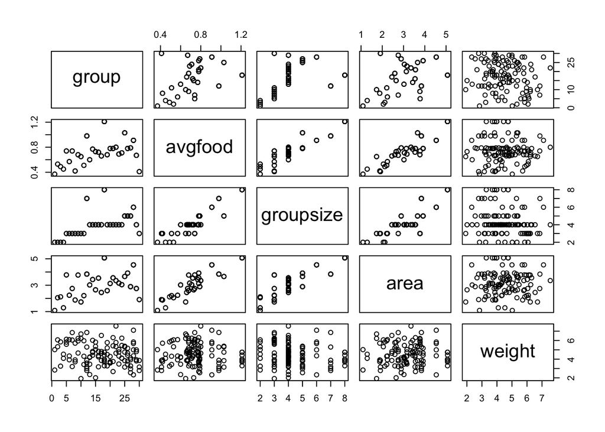

```r
pairs(foxes)
```

Since average food is likely a function of both the size of the group, and the size of the group’s territory from which food can be derived, average food should be excluded from the model.